# Grupo 1: Palmeiras do JBRJ

## Seria possível ajustar um bom modelo para explicar a relação entre altura e DAP para Roystonea?

```r
# Filtrar Roystonea
Roystonea <- palmeira %>%
  filter(genus == "Roystonea")
```

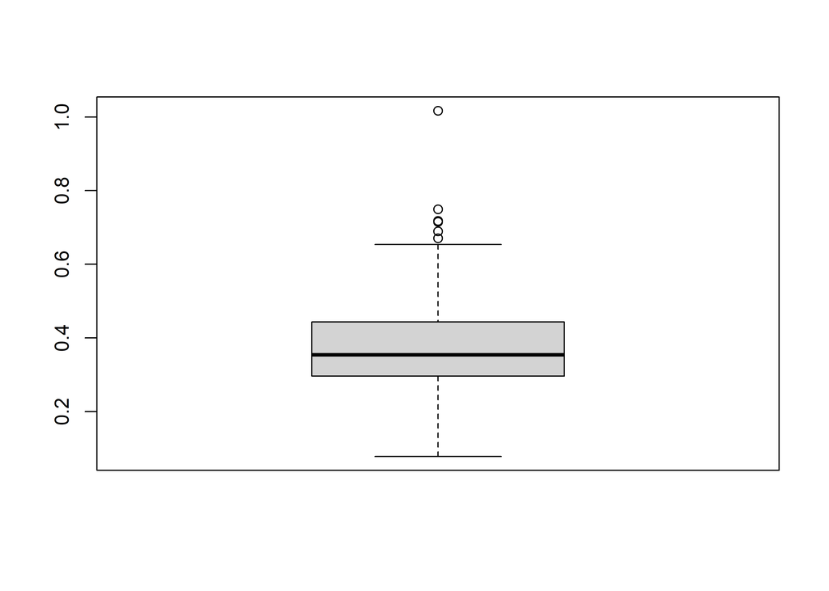

```r
boxplot(Roystonea$rel_hd)
```

```r
# Limites para detectar outliers
Q1 <- quantile(Roystonea$rel_hd, 0.25, na.rm = TRUE)
Q3 <- quantile(Roystonea$rel_hd, 0.75, na.rm = TRUE)

IQR_alt <- IQR(Roystonea$rel_hd, na.rm = TRUE)

lim_inf <- Q1 - 1.5 * IQR_alt
lim_sup <- Q3 + 1.5 * IQR_alt

# Filtrar sem outliers
Roystonea_sem_out <- Roystonea %>%
  filter(
    rel_hd >= lim_inf,
    rel_hd <= lim_sup
  )
```

```r
Roystonea_sem_out <- Roystonea_sem_out[-c(525, 533, 354, 231, 32), ]
```

```r
# Modelo linear
modelo_lm_roys <- lm(altura ~ dap, data = Roystonea_sem_out)
```

```r
shapiro.test(modelo_lm_roys$residuals)
```

```
##
##  Shapiro-Wilk normality test
##
## data:  modelo_lm_roys$residuals
## W = 0.99448, p-value = 0.05373
```

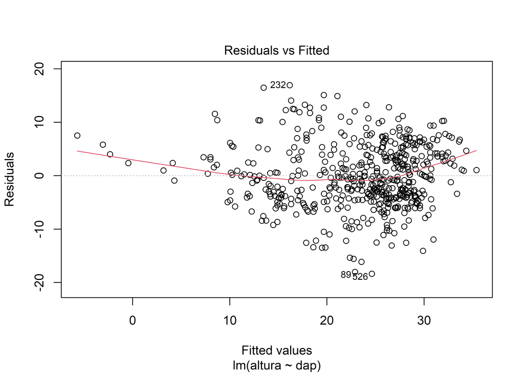

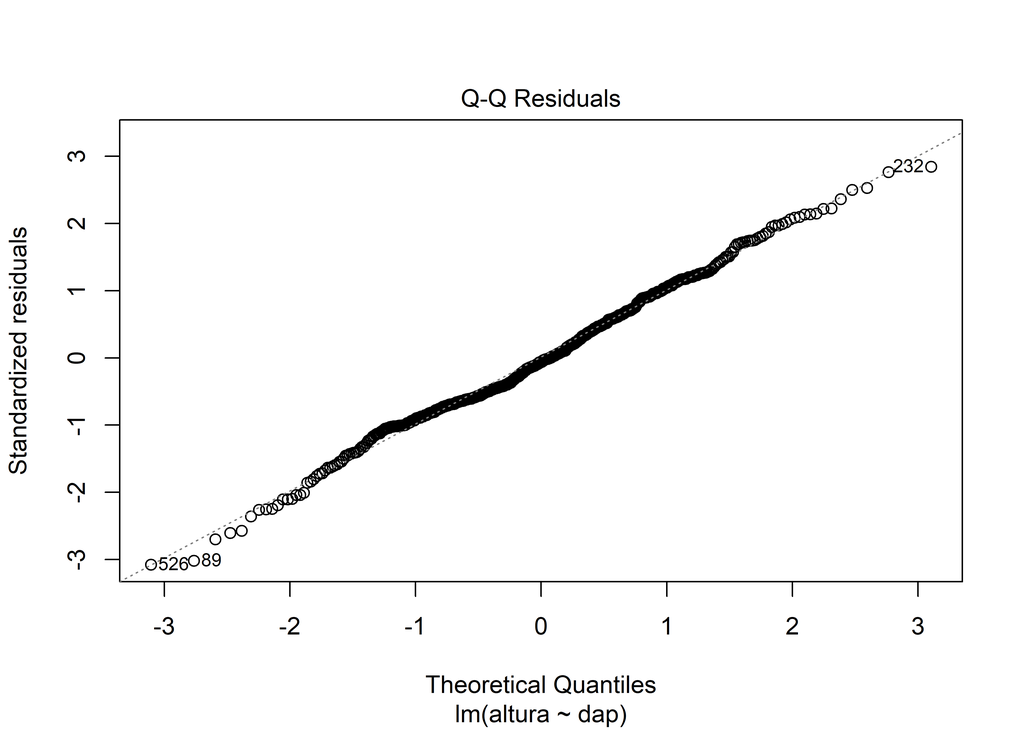

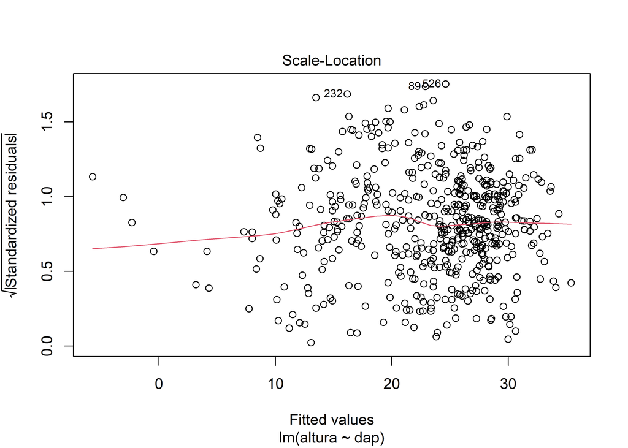

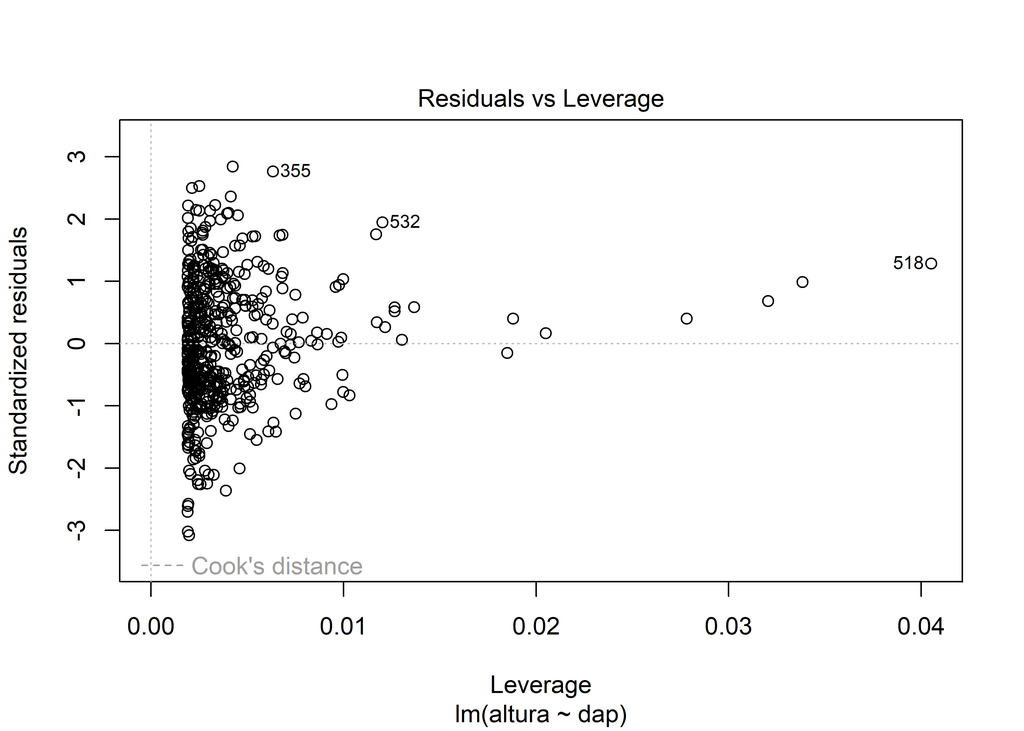

```r
# Os modelo avaliados nao atenderam os pressupostos, principalmente na homogenidade das variancias.
# Resumo do modelo
plot(modelo_lm_roys)
```

```r
# Modelo quadrático
modelo_quad_roys <- lm(altura ~ dap + I(dap^2), data = Roystonea_sem_out)
```

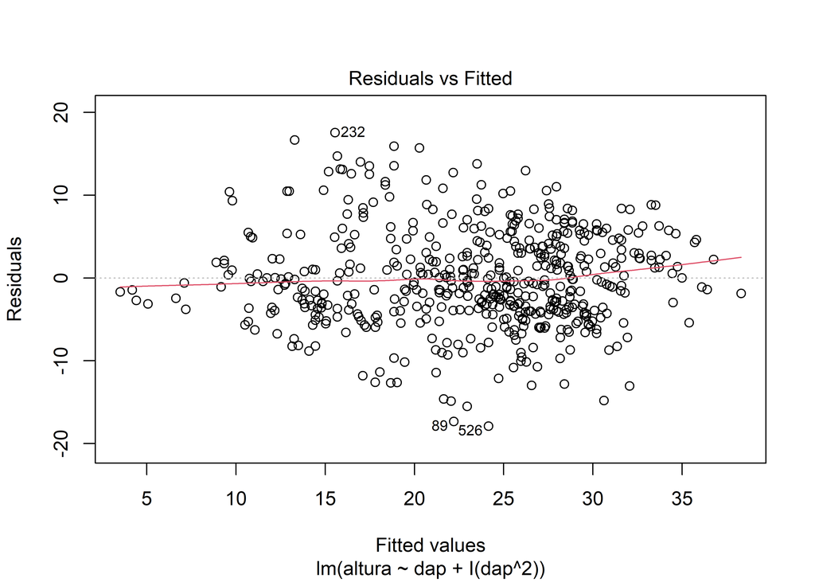

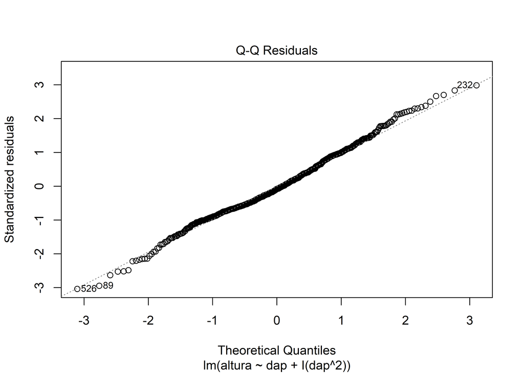

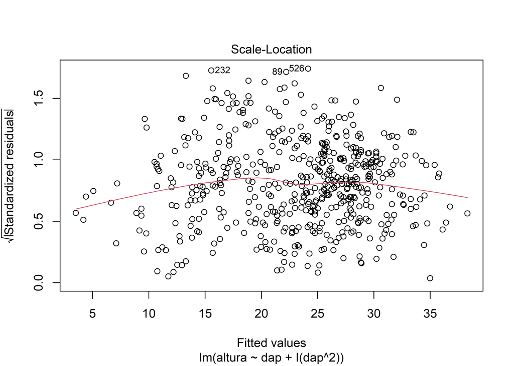

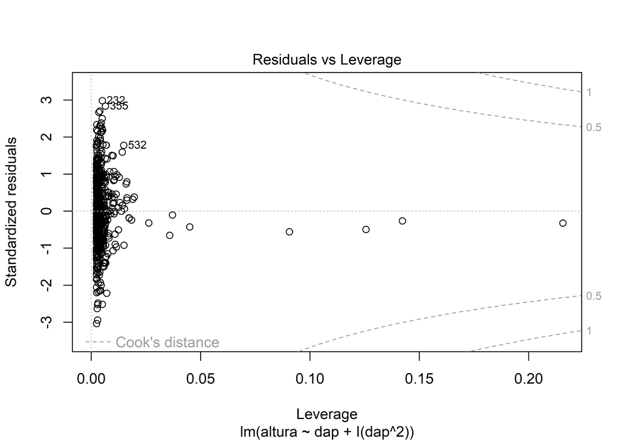

```r
plot(modelo_quad_roys)
```

```r
shapiro.test(modelo_quad_roys$residuals)
```

```
##
##  Shapiro-Wilk normality test
##
## data:  modelo_quad_roys$residuals
## W = 0.99312, p-value = 0.01621
```

```r
# Modelo log
modelo_log_roys <- lm(altura ~ log(dap), data = Roystonea_sem_out)
```

```r
shapiro.test(modelo_log_roys$residuals)
```

```
##
##  Shapiro-Wilk normality test
##
## data:  modelo_log_roys$residuals
## W = 0.99272, p-value = 0.01145
```

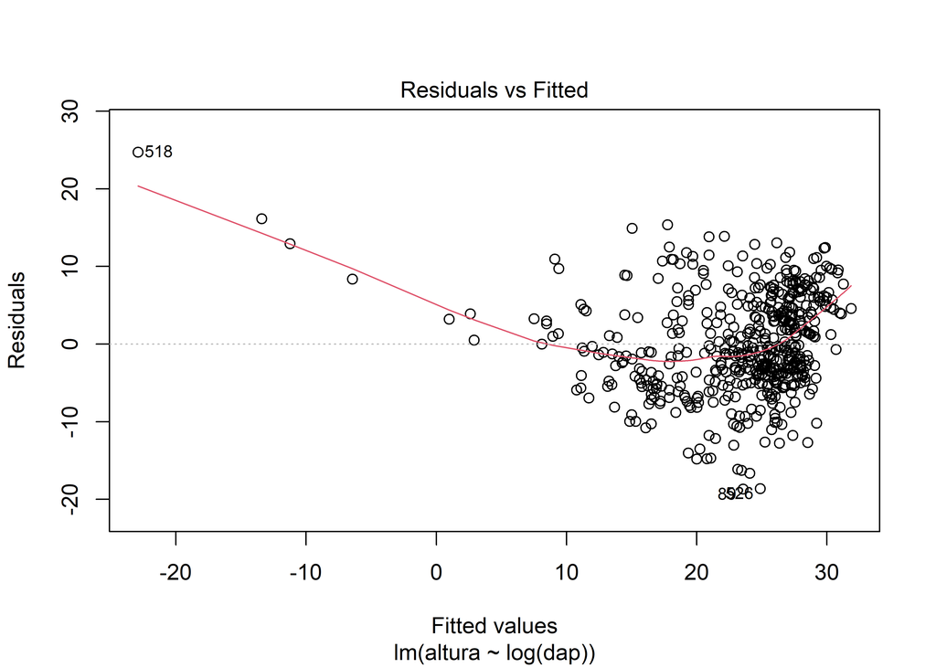

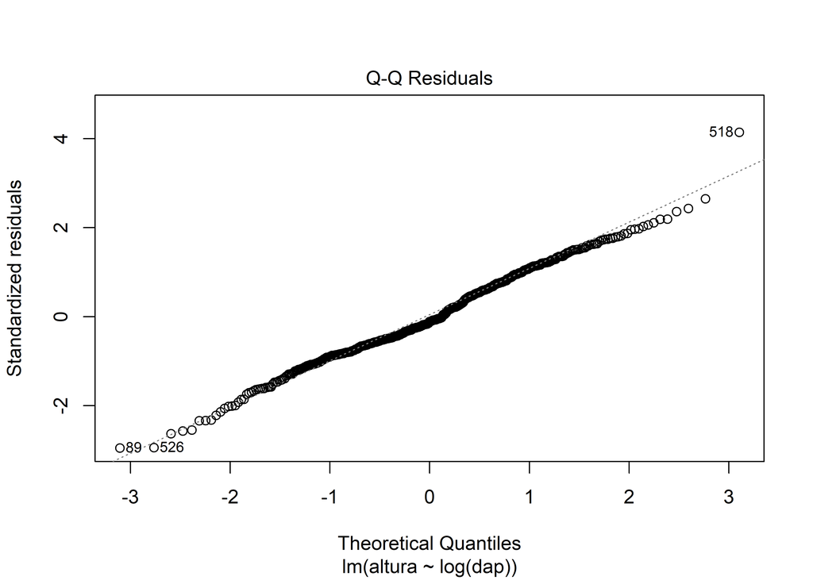

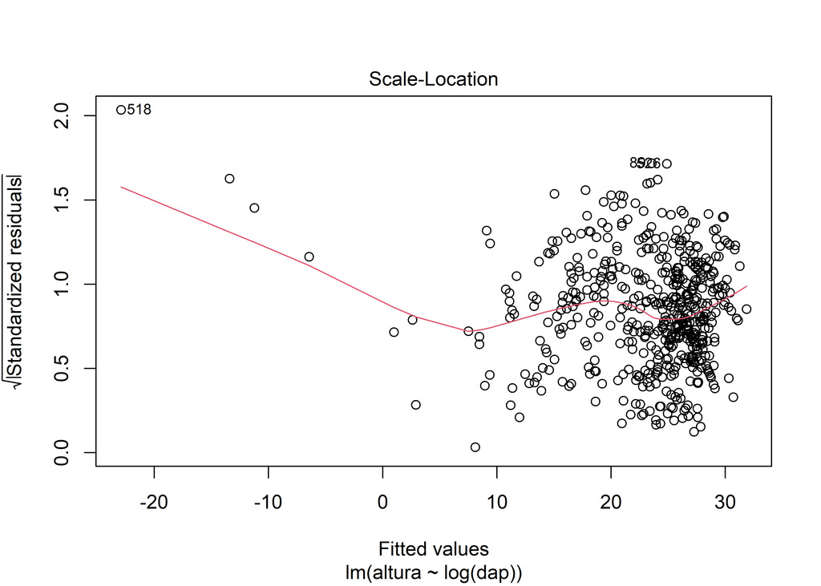

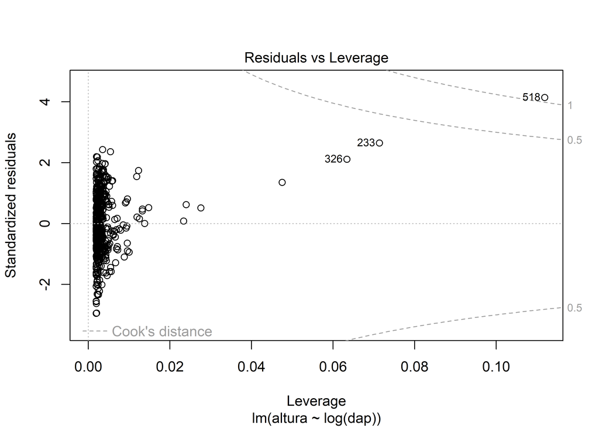

```r
plot(modelo_log_roys)
```

### 🔴 Sugestão do professor

Aqui, vocês poderiam ter utilizado o script que enviei após a aula, no qual foram ajustados alguns modelos para *Roystonea*, considerando espécie como covariável e canteiros como efeito aleatório.

De qualquer forma, vocês também poderiam ter testado formalmente a homogeneidade das variâncias e observado que o modelo linear atendeu aos pressupostos. Vejam o código abaixo:

```r
library(lmtest)
```

```r
# Testando homogeneidade no modelo linear
bptest(modelo_lm_roys)
```

```
##
##  studentized Breusch-Pagan test
##
## data:  modelo_lm_roys
## BP = 2.6761, df = 1, p-value = 0.1019
```

```r
# Resultados da regressão
summary(modelo_lm_roys)
```

```
##
## Call:
## lm(formula = altura ~ dap, data = Roystonea_sem_out)
##
## Residuals:
##      Min       1Q   Median       3Q      Max
## -18.3641  -3.9267  -0.3472   4.0561  16.9546
##
## Coefficients:
##              Estimate Std. Error t value Pr(>|t|)
## (Intercept) -11.96176    1.45153  -8.241 1.37e-15 ***
## dap           0.55510    0.02248  24.690  < 2e-16 ***
## ---
## Signif. codes:  0 '***' 0.001 '**' 0.01 '*' 0.05 '.' 0.1 ' ' 1
##
## Residual standard error: 5.973 on 526 degrees of freedom
## Multiple R-squared:  0.5368, Adjusted R-squared:  0.5359
## F-statistic: 609.6 on 1 and 526 DF,  p-value: < 2.2e-16
```

```r
library(ggpmisc)
```

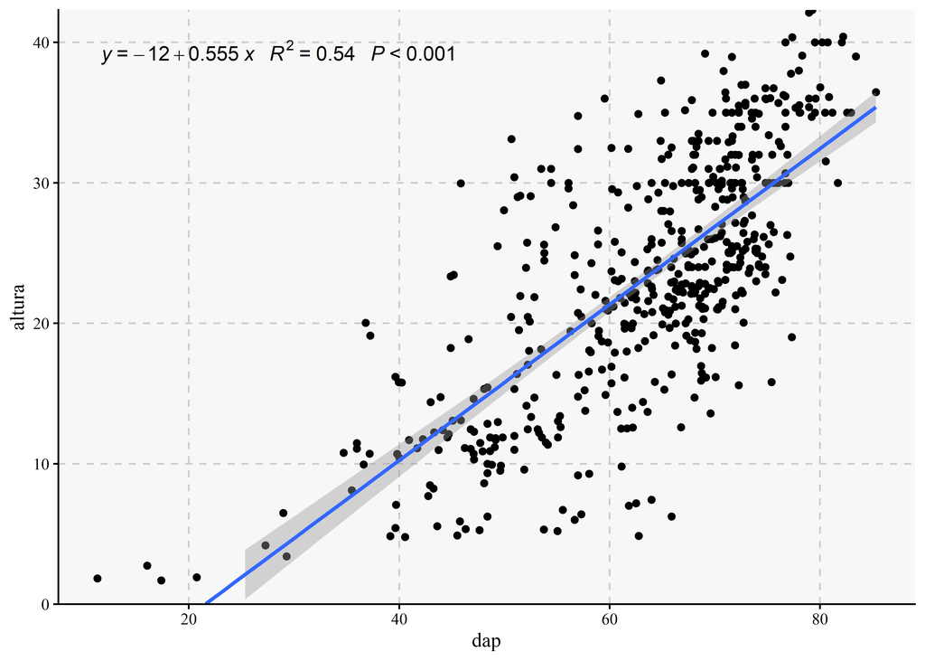

```r
# Visualização do modelo
ggplot(data = Roystonea_sem_out, aes(x = dap, y = altura)) +
  geom_point() +
  geom_smooth(method = "lm", formula = y ~ x, se = TRUE) +
  stat_poly_eq(formula = y ~ x, aes(label = paste(after_stat(eq.label), after_stat(rr.label), after_stat(p.value.label), sep = "~~~")), parse = TRUE) +
  scale_y_continuous(limits = c(0, NA), expand = c(0, 0)) +
  theme_classic() +
  theme(text = element_text(family = "serif"),
        panel.grid.major.y = element_line(linetype = "dashed", color = "gray80"),
        panel.grid.major.x = element_line(linetype = "dashed", color = "gray80"),
        panel.background = element_rect(fill = "grey97"))
```

```r
# Testando homogeneidade no modelo quadrático
bptest(modelo_quad_roys)
```

```
##
##  studentized Breusch-Pagan test
##
## data:  modelo_quad_roys
## BP = 17.582, df = 2, p-value = 0.0001521
```

```r
# Testando homogeneidade no modelo log
bptest(modelo_log_roys)
```

```
##
##  studentized Breusch-Pagan test
##
## data:  modelo_log_roys
## BP = 31.609, df = 1, p-value = 1.885e-08
```

## Há diferenças de altura entre palmeiras com caule único e multiplos caules? E entre os principais gêneros da família?

#### Gráfico para visualizar a diferença de altura entre palmeiras com caule único e multiplos caules

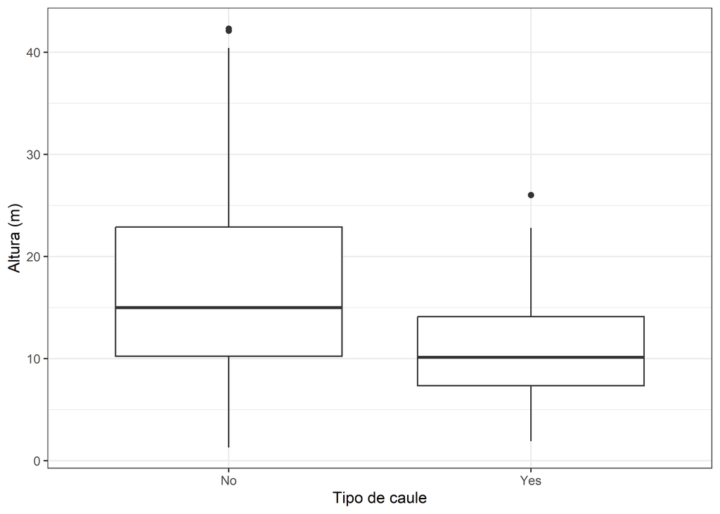

```r
#Gráfico
ggplot(palmeira,
       aes(x = multicaule_l,
           y = altura)) +
  geom_boxplot() +
  theme_bw() +
  labs(x = "Tipo de caule",
       y = "Altura (m)")
```

```r
#teste shapiro
shapiro.test(palmeira$altura)
```

```
##
##  Shapiro-Wilk normality test
##
## data:  palmeira$altura
## W = 0.96117, p-value < 2.2e-16
```

```r
#Distribuição não normal
```

#### Teste para ver a diferença

```r
#Wilcox
wilcox.test(
  altura ~ multicaule_l,
  data = palmeira
)
```

```
##
##  Wilcoxon rank sum test with continuity correction
##
## data:  altura by multicaule_l
## W = 108310, p-value = 6.395e-14
## alternative hypothesis: true location shift is not equal to 0
```

```r
#É diferente
```

### E entre os principais gêneros da família?

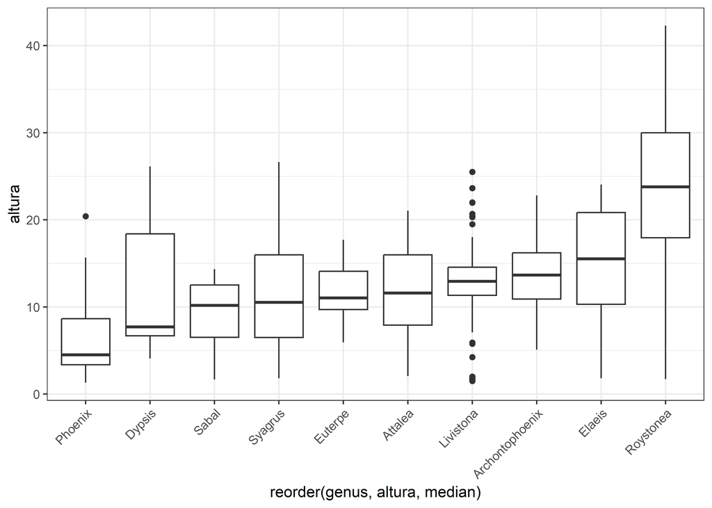

```r
#PLOT GENERO
ggplot(palmeira2,
       aes(x = reorder(genus, altura, median),
           y = altura)) +
  geom_boxplot() +
  theme_bw() +
  theme(
    axis.text.x = element_text(
      angle = 45,
      hjust = 1
    )
  )
```

#### Teste para ver diferença

```r
#Teste de kruskal
kruskal.test(
  altura ~ genus,
  data = palmeira2
)
```

```
##
##  Kruskal-Wallis rank sum test
##
## data:  altura by genus
## Kruskal-Wallis chi-squared = 452, df = 9, p-value < 2.2e-16
```

```r
#Para ver diferença entre grupos
## Pós teste kruskal: Teste de Dunn com PMCMR
#install.packages("PMCMRplus")
#Primeiro voce transforma o sua variavel de comparacao em fator
library(PMCMRplus)

## Dunn's all-pairs comparison test

#Primeiro voce transforma o sua variavel de comparacao em fator
palmeira2$genus <- as.factor(palmeira2$genus)

ph_genero <-kwAllPairsDunnTest(palmeira2$altura~palmeira2$genus, data = palmeira2,
                          p.adjust.method = "bonferroni", list = TRUE)
summary(ph_genero)
```

```
##                                  z value   Pr(>|z|)
## Attalea - Archontophoenix == 0     1.376 1.00000000
## Dypsis - Archontophoenix == 0      1.274 1.00000000
## Elaeis - Archontophoenix == 0      0.626 1.00000000
## Euterpe - Archontophoenix == 0     1.455 1.00000000
## Livistona - Archontophoenix == 0   0.756 1.00000000
## Phoenix - Archontophoenix == 0     4.415 0.00045546 ***
## Roystonea - Archontophoenix == 0   6.039 6.9621e-08 ***
## Sabal - Archontophoenix == 0       2.314 0.93018518
## Syagrus - Archontophoenix == 0     1.300 1.00000000
## Dypsis - Attalea == 0              0.213 1.00000000
## Elaeis - Attalea == 0              2.187 1.00000000
## Euterpe - Attalea == 0             0.316 1.00000000
## Livistona - Attalea == 0           0.937 1.00000000
## Phoenix - Attalea == 0             3.895 0.00441856  **
## Roystonea - Attalea == 0          11.330 < 2.22e-16 ***
## Sabal - Attalea == 0               1.476 1.00000000
## Syagrus - Attalea == 0             0.041 1.00000000
## Elaeis - Dypsis == 0               1.895 1.00000000
## Euterpe - Dypsis == 0              0.058 1.00000000
## Livistona - Dypsis == 0            0.853 1.00000000
## Phoenix - Dypsis == 0              2.826 0.21189900
## Roystonea - Dypsis == 0            7.117 4.9536e-11 ***
## Sabal - Dypsis == 0                1.076 1.00000000
## Syagrus - Dypsis == 0              0.168 1.00000000
## Euterpe - Elaeis == 0              2.148 1.00000000
## Livistona - Elaeis == 0            1.585 1.00000000
## Phoenix - Elaeis == 0              5.206 8.6778e-06 ***
## Roystonea - Elaeis == 0            5.494 1.7638e-06 ***
## Sabal - Elaeis == 0                2.912 0.16147452
## Syagrus - Elaeis == 0              2.036 1.00000000
## Livistona - Euterpe == 0           1.058 1.00000000
## Phoenix - Euterpe == 0             3.053 0.10192500
## Roystonea - Euterpe == 0           8.478 1.0291e-15 ***
## Sabal - Euterpe == 0               1.101 1.00000000
## Syagrus - Euterpe == 0             0.255 1.00000000
## Phoenix - Livistona == 0           4.851 5.5386e-05 ***
## Roystonea - Livistona == 0        11.920 < 2.22e-16 ***
## Sabal - Livistona == 0             2.098 1.00000000
## Syagrus - Livistona == 0           0.846 1.00000000
## Roystonea - Phoenix == 0          12.820 < 2.22e-16 ***
## Sabal - Phoenix == 0               1.460 1.00000000
## Syagrus - Phoenix == 0             3.519 0.01949396   *
## Sabal - Roystonea == 0             7.762 3.7642e-13 ***
## Syagrus - Roystonea == 0           9.248 < 2.22e-16 ***
## Syagrus - Sabal == 0               1.363 1.00000000
```

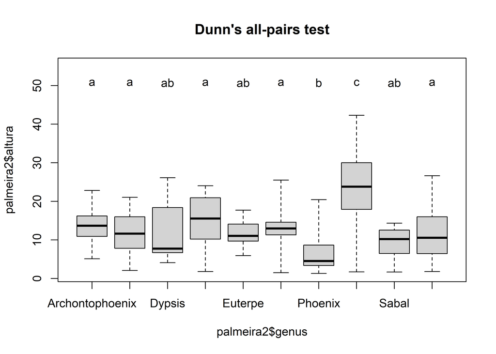

```r
plot(ph_genero)
```

### 🔴 Sugestão do professor

A solução proposta foi muito boa, mas o gráfico ficou pouco legível. Vocês poderiam ter utilizado ferramentas de IA para auxiliar na edição da visualização e melhorar sua apresentação. Além disso, foram gerados muitos outputs em um único *chunk*, o que produz várias janelas de resultados e torna a visualização e a renderização do Markdown confusas. Vejam abaixo:

```r
# Realizando o teste de Kruskal-Wallis
kruskal.test(altura ~ genus, data = palmeira2)
```

```
##
##  Kruskal-Wallis rank sum test
##
## data:  altura by genus
## Kruskal-Wallis chi-squared = 452, df = 9, p-value < 2.2e-16
```

```r
# Realizando o teste de Dunn
ph_genero <- kwAllPairsDunnTest(altura ~ genus, data = palmeira2, p.adjust.method = "holm")

summary(ph_genero)
```

```
##                                  z value   Pr(>|z|)
## Attalea - Archontophoenix == 0     1.376 1.00000000
## Dypsis - Archontophoenix == 0      1.274 1.00000000
## Elaeis - Archontophoenix == 0      0.626 1.00000000
## Euterpe - Archontophoenix == 0     1.455 1.00000000
## Livistona - Archontophoenix == 0   0.756 1.00000000
## Phoenix - Archontophoenix == 0     4.415 0.00034412 ***
## Roystonea - Archontophoenix == 0   6.039 5.8791e-08 ***
## Sabal - Archontophoenix == 0       2.314 0.57878189
## Syagrus - Archontophoenix == 0     1.300 1.00000000
## Dypsis - Attalea == 0              0.213 1.00000000
## Elaeis - Attalea == 0              2.187 0.77639614
## Euterpe - Attalea == 0             0.316 1.00000000
## Livistona - Attalea == 0           0.937 1.00000000
## Phoenix - Attalea == 0             3.895 0.00324027  **
## Roystonea - Attalea == 0          11.330 < 2.22e-16 ***
## Sabal - Attalea == 0               1.476 1.00000000
## Syagrus - Attalea == 0             0.041 1.00000000
## Elaeis - Dypsis == 0               1.895 1.00000000
## Euterpe - Dypsis == 0              0.058 1.00000000
## Livistona - Dypsis == 0            0.853 1.00000000
## Phoenix - Dypsis == 0              2.826 0.13655713
## Roystonea - Dypsis == 0            7.117 4.2931e-11 ***
## Sabal - Dypsis == 0                1.076 1.00000000
## Syagrus - Dypsis == 0              0.168 1.00000000
## Euterpe - Elaeis == 0              2.148 0.82495526
## Livistona - Elaeis == 0            1.585 1.00000000
## Phoenix - Elaeis == 0              5.206 6.9422e-06 ***
## Roystonea - Elaeis == 0            5.494 1.4503e-06 ***
## Sabal - Elaeis == 0                2.912 0.10764968
## Syagrus - Elaeis == 0              2.036 1.00000000
## Livistona - Euterpe == 0           1.058 1.00000000
## Phoenix - Euterpe == 0             3.053 0.07021500   .
## Roystonea - Euterpe == 0           8.478 9.3758e-16 ***
## Sabal - Euterpe == 0               1.101 1.00000000
## Syagrus - Euterpe == 0             0.255 1.00000000
## Phoenix - Livistona == 0           4.851 4.3078e-05 ***
## Roystonea - Livistona == 0        11.920 < 2.22e-16 ***
## Sabal - Livistona == 0             2.098 0.89781885
## Syagrus - Livistona == 0           0.846 1.00000000
## Roystonea - Phoenix == 0          12.820 < 2.22e-16 ***
## Sabal - Phoenix == 0               1.460 1.00000000
## Syagrus - Phoenix == 0             3.519 0.01386237   *
## Sabal - Roystonea == 0             7.762 3.3459e-13 ***
## Syagrus - Roystonea == 0           9.248 < 2.22e-16 ***
## Syagrus - Sabal == 0               1.363 1.00000000
```

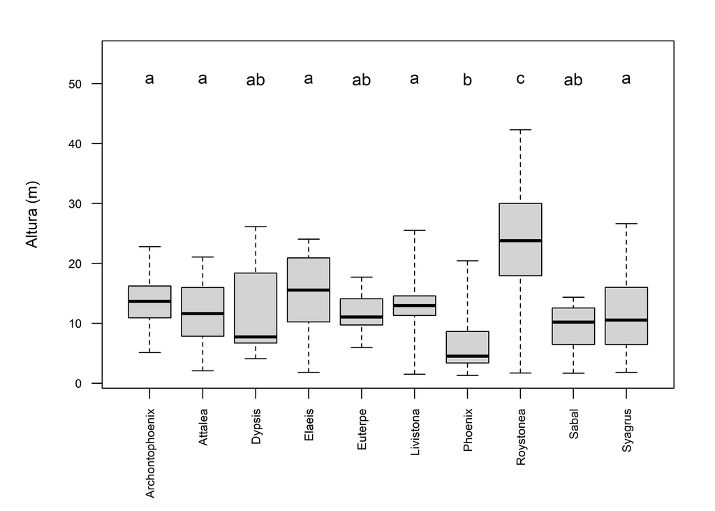

```r
# Visualizando resultados
par(mar = c(6, 5, 2, 2), las = 2, cex.axis = 0.7, cex.lab = 0.9)

plot(ph_genero, ylab = "Altura (m)", xlab = "", main = "")
```